# California Housing Price Prediction

### submitted by - GAURAV VATSA, Cohort VI-PGPDS, vatsa.gaurav@gmail.com

Problem Objective :

The project aims at building a model of housing prices to predict median house values in California using the provided dataset. This model should learn from the data and be able to predict the median housing price in any district, given all the other metrics.

Districts or block groups are the smallest geographical units for which the US Census Bureau publishes sample data (a block group typically has a population of 600 to 3,000 people). There are 20,640 districts in the project dataset.

Analysis Tasks to be performed:

1. Build a model of housing prices to predict median house values in California using the provided dataset.
2. Train the model to learn from the data to predict the median housing price in any district, given all the other metrics.
3. Predict housing prices based on median_income and plot the regression chart for it.

```python
import os
```

```python
os.getcwd()
```

```
'C:\\Users\\Gaurav74110\\1.Projects & Assignments'
```

```python
os.chdir(r"C:\Backup\Python\Datasets")
```

```python
import pandas as pd
import numpy as np
import matplotlib.pyplot as plt
```

### 1. Load the data :

• Read the “housing.csv” file from the folder into the program.

• Print first few rows of this data.

• Extract input (X) and output (Y) data from the dataset.

```python
Calif = pd.read_excel(r"1553768847_housing.xlsx")
Calif.head()
```

|  | longitude | latitude | housing_median_age | total_rooms | total_bedrooms | population | households | median_income | ocean_proximity | median_house_value |
| --- | --- | --- | --- | --- | --- | --- | --- | --- | --- | --- |
| 0 | -122.23 | 37.88 | 41 | 880 | 129.0 | 322 | 126 | 8.3252 | NEAR BAY | 452600 |
| 1 | -122.22 | 37.86 | 21 | 7099 | 1106.0 | 2401 | 1138 | 8.3014 | NEAR BAY | 358500 |
| 2 | -122.24 | 37.85 | 52 | 1467 | 190.0 | 496 | 177 | 7.2574 | NEAR BAY | 352100 |
| 3 | -122.25 | 37.85 | 52 | 1274 | 235.0 | 558 | 219 | 5.6431 | NEAR BAY | 341300 |
| 4 | -122.25 | 37.85 | 52 | 1627 | 280.0 | 565 | 259 | 3.8462 | NEAR BAY | 342200 |

```python
Calif.dtypes
```

```
longitude             float64
latitude              float64
housing_median_age      int64
total_rooms             int64
total_bedrooms        float64
population              int64
households              int64
median_income         float64
ocean_proximity        object
median_house_value      int64
dtype: object
```

```python
Calif.describe()
```

|  | longitude | latitude | housing_median_age | total_rooms | total_bedrooms | population | households | median_income | median_house_value |
| --- | --- | --- | --- | --- | --- | --- | --- | --- | --- |
| count | 20640.000000 | 20640.000000 | 20640.000000 | 20640.000000 | 20433.000000 | 20640.000000 | 20640.000000 | 20640.000000 | 20640.000000 |
| mean | -119.569704 | 35.631861 | 28.639486 | 2635.763081 | 537.870553 | 1425.476744 | 499.539680 | 3.870671 | 206855.816909 |
| std | 2.003532 | 2.135952 | 12.585558 | 2181.615252 | 421.385070 | 1132.462122 | 382.329753 | 1.899822 | 115395.615874 |
| min | -124.350000 | 32.540000 | 1.000000 | 2.000000 | 1.000000 | 3.000000 | 1.000000 | 0.499900 | 14999.000000 |
| 25% | -121.800000 | 33.930000 | 18.000000 | 1447.750000 | 296.000000 | 787.000000 | 280.000000 | 2.563400 | 119600.000000 |
| 50% | -118.490000 | 34.260000 | 29.000000 | 2127.000000 | 435.000000 | 1166.000000 | 409.000000 | 3.534800 | 179700.000000 |
| 75% | -118.010000 | 37.710000 | 37.000000 | 3148.000000 | 647.000000 | 1725.000000 | 605.000000 | 4.743250 | 264725.000000 |
| max | -114.310000 | 41.950000 | 52.000000 | 39320.000000 | 6445.000000 | 35682.000000 | 6082.000000 | 15.000100 | 500001.000000 |

```python
# Longitude and Latitude data typically does not impact housing prices. Hence we drop these two variables.
Calif = Calif.drop(["longitude", "latitude"], axis=1)
Calif[:3]
```

|  | housing_median_age | total_rooms | total_bedrooms | population | households | median_income | ocean_proximity | median_house_value |
| --- | --- | --- | --- | --- | --- | --- | --- | --- |
| 0 | 41 | 880 | 129.0 | 322 | 126 | 8.3252 | NEAR BAY | 452600 |
| 1 | 21 | 7099 | 1106.0 | 2401 | 1138 | 8.3014 | NEAR BAY | 358500 |
| 2 | 52 | 1467 | 190.0 | 496 | 177 | 7.2574 | NEAR BAY | 352100 |

```python
Calif.shape
```

```
(20640, 8)
```

[figure not shown]

We can safely assume that barring latitude and longitude all other input variables (features) do impact the housing prices (the target variable - Median House Value)

## 2. Handle missing values :

• Fill the missing values with the mean of the respective column.

```python
Calif.isnull().sum()
```

```
housing_median_age      0
total_rooms             0
total_bedrooms        207
population              0
households              0
median_income           0
ocean_proximity         0
median_house_value      0
dtype: int64
```

The col total_bedrooms has 207 missing value. We will fill these with the mean of total_bedrooms.

```python
Calif["total_bedrooms"].fillna(np.mean(Calif["total_bedrooms"]), inplace = True)
```

```python
# Check if the null values have been replaced
Calif.isnull().sum()
```

```
housing_median_age    0
total_rooms           0
total_bedrooms        0
population            0
households            0
median_income         0
ocean_proximity       0
median_house_value    0
dtype: int64
```

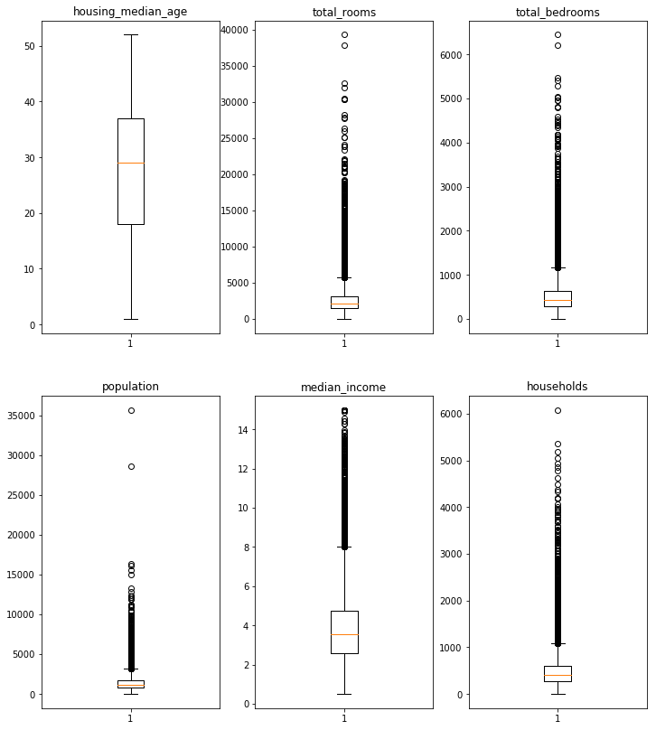

```python
# A quick glance at the variables for look for outliers.
%matplotlib inline
fig, ((ax1,ax2,ax3),(ax4,ax5,ax6)) = plt.subplots(2,3,figsize = (12,14))
ax1.boxplot(Calif["housing_median_age"])
ax1.set_title("housing_median_age")
ax2.boxplot(Calif["total_rooms"])
ax2.set_title("total_rooms")
ax3.boxplot(Calif["total_bedrooms"])
ax3.set_title("total_bedrooms")
ax4.boxplot(Calif["population"])
ax4.set_title("population")
ax5.boxplot(Calif["median_income"])
ax5.set_title("median_income")
ax6.boxplot(Calif["households"])
ax6.set_title("households")
#ax7.boxplot(Calif["ocean_proximity"])
plt.show()
```

## 3. Encode categorical data :

• Convert categorical column in the dataset to numerical data.

```python
# We observe above that "ocean_proximity" is the categorical variable in the date
# data.groupby("ocean_proximity").sum()
Calif.ocean_proximity.value_counts()
```

```
<1H OCEAN     9136
INLAND        6551
NEAR OCEAN    2658
NEAR BAY      2290
ISLAND           5
Name: ocean_proximity, dtype: int64
```

```python
# As observed there are five categories for the ocean_proximity column
# We convert this into numerical data using LabelEncoder
from sklearn.preprocessing import LabelEncoder
```

```python
encoder = LabelEncoder()
Calif["ocean_proximity"] = encoder.fit_transform(Calif["ocean_proximity"])
```

```python
Calif.ocean_proximity.value_counts()
```

```
0    9136
1    6551
4    2658
3    2290
2       5
Name: ocean_proximity, dtype: int64
```

```python
Calif.head()
```

|  | housing_median_age | total_rooms | total_bedrooms | population | households | median_income | ocean_proximity | median_house_value |
| --- | --- | --- | --- | --- | --- | --- | --- | --- |
| 0 | 41 | 880 | 129.0 | 322 | 126 | 8.3252 | 3 | 452600 |
| 1 | 21 | 7099 | 1106.0 | 2401 | 1138 | 8.3014 | 3 | 358500 |
| 2 | 52 | 1467 | 190.0 | 496 | 177 | 7.2574 | 3 | 352100 |
| 3 | 52 | 1274 | 235.0 | 558 | 219 | 5.6431 | 3 | 341300 |
| 4 | 52 | 1627 | 280.0 | 565 | 259 | 3.8462 | 3 | 342200 |

As we see - the categorical data has been converted to numerical data, dtype: int64

## 4. Split the dataset :

• Split the data into 80% training dataset and 20% test dataset.

```python
Y = Calif.iloc[:,7] #Output
X = Calif.iloc[:,0:7] #Input
```

```python
X[:3]
```

|  | housing_median_age | total_rooms | total_bedrooms | population | households | median_income | ocean_proximity |
| --- | --- | --- | --- | --- | --- | --- | --- |
| 0 | 41 | 880 | 129.0 | 322 | 126 | 8.3252 | 3 |
| 1 | 21 | 7099 | 1106.0 | 2401 | 1138 | 8.3014 | 3 |
| 2 | 52 | 1467 | 190.0 | 496 | 177 | 7.2574 | 3 |

```python
Y[:3]
```

```
0    452600
1    358500
2    352100
Name: median_house_value, dtype: int64
```

```python
from sklearn.model_selection import train_test_split
X_train, X_test, Y_train, Y_test = train_test_split(X,Y, test_size = .2, random_state = 555)
```

```python
X_train.shape, X_test.shape, Y_train.shape, Y_test.shape
```

```
((16512, 7), (4128, 7), (16512,), (4128,))
```

## 5. Standardize data :

• Standardize training and test datasets.

```python
from sklearn.preprocessing import StandardScaler
s = StandardScaler()
```

```python
s.fit(X_train)

X_train_std = s.transform(X_train)
X_test_std = s.transform(X_test)
```

## 6. Perform Linear Regression :

• Perform Linear Regression on training data.  
• Predict output for test dataset using the fitted model.  
• Print root mean squared error (RMSE) from Linear Regression. [ HINT: Import mean_squared_error from sklearn.metrics ]

```python
from sklearn.linear_model import LinearRegression
lm = LinearRegression()
lm.fit(X_train_std, Y_train)
```

```
LinearRegression(copy_X=True, fit_intercept=True, n_jobs=1, normalize=False)
```

```python
# Predict output for test dataset using the fitted model.
Y_test_pred = lm.predict(X_test_std)
Y_test_pred
```

```
array([ 142718.96177711,  637491.18654436,  188442.16711137, ...,
        221492.03631486,  214594.52937888,  211296.3122414 ])
```

```python
# Print root mean squared error (RMSE) from Linear Regression
from sklearn.metrics import mean_squared_error
RMSE = np.sqrt(mean_squared_error(Y_test,Y_test_pred))
RMSE
```

```
75402.59504385812
```

```python
TestvsPred = pd.DataFrame({"Actual": Y_test, "Predicted": Y_test_pred})
TestvsPred.head(25)
```

|  | Actual | Predicted |
| --- | --- | --- |
| 19278 | 131100 | 142718.961777 |
| 5352 | 500001 | 637491.186544 |
| 6923 | 155100 | 188442.167111 |
| 9736 | 227200 | 143815.203374 |
| 18757 | 65600 | 89346.666052 |
| 10362 | 197200 | 243607.562195 |
| 11453 | 447700 | 290099.818773 |
| 4426 | 192500 | 155971.182111 |
| 4514 | 136300 | 144797.527975 |
| 15261 | 369800 | 297720.919858 |
| 18788 | 105700 | 126141.530377 |
| 9061 | 85400 | 163021.595992 |
| 13706 | 80400 | 94071.716887 |
| 8173 | 235000 | 230530.075343 |
| 16846 | 284100 | 270588.227740 |
| 11148 | 170700 | 273807.457560 |
| 2188 | 57800 | 82077.208551 |
| 12910 | 150500 | 194910.103626 |
| 5328 | 277500 | 263680.989922 |
| 4684 | 175000 | 227398.188391 |
| 1925 | 87500 | 210741.070989 |
| 17394 | 113300 | 138025.634129 |
| 392 | 206300 | 197449.678831 |
| 11465 | 252900 | 201690.546397 |
| 19276 | 141000 | 157910.293260 |

```python
from sklearn import metrics
```

```python
print('Mean Absolute Error:', metrics.mean_absolute_error(Y_test, Y_test_pred))
print('Mean Squared Error:', metrics.mean_squared_error(Y_test, Y_test_pred))
print('Root Mean Squared Error:', np.sqrt(metrics.mean_squared_error(Y_test, Y_test_pred)))
```

```
Mean Absolute Error: 55632.375602
Mean Squared Error: 5685551339.35
Root Mean Squared Error: 75402.5950439
```

```python
lm.score(X_test_std, Y_test_pred)
```

```
1.0
```

## 7. Bonus exercise: Perform Linear Regression with one independent variable :

• Extract just the median_income column from the independent variables (from X_train and X_test).  
• Perform Linear Regression to predict housing values based on median_income.  
• Predict output for test dataset using the fitted model.  
• Plot the fitted model for training data as well as for test data to check if the fitted model satisfies the test data.

```python
X_train.head()
```

|  | housing_median_age | total_rooms | total_bedrooms | population | households | median_income | ocean_proximity |
| --- | --- | --- | --- | --- | --- | --- | --- |
| 15000 | 33 | 3880 | 770.0 | 2288 | 805 | 3.6848 | 4 |
| 16739 | 24 | 4299 | 857.0 | 2249 | 788 | 4.6098 | 3 |
| 4925 | 43 | 863 | 206.0 | 788 | 187 | 0.9463 | 0 |
| 4834 | 35 | 1090 | 345.0 | 1605 | 330 | 2.1518 | 0 |
| 16277 | 43 | 1610 | 412.0 | 1409 | 365 | 1.7574 | 1 |

```python
X_train_medInc = X_train.iloc[:,5:6]
X_train_medInc.head()
```

|  | median_income |
| --- | --- |
| 15000 | 3.6848 |
| 16739 | 4.6098 |
| 4925 | 0.9463 |
| 4834 | 2.1518 |
| 16277 | 1.7574 |

```python
X_test_medInc = X_test.iloc[:,5:6]
X_test_medInc.head()
```

|  | median_income |
| --- | --- |
| 19278 | 2.5735 |
| 5352 | 12.8483 |
| 6923 | 3.9091 |
| 9736 | 3.0347 |
| 18757 | 2.2120 |

```python
model2 = lm.fit(X_train_medInc, Y_train)
Y_medInc_pred = lm.predict(X_test_medInc)
Y_medInc_pred
```

```
array([ 152789.96643639,  581375.79036164,  208500.95121804, ...,
        224747.90282965,  234712.97790028,  186697.91756622])
```

```python
#from sklearn.metrics import mean_squared_error
RMSE_model2 = np.sqrt(mean_squared_error(Y_test,Y_medInc_pred))
RMSE_model2
```

```
82838.469184483867
```

```python
print('Mean Absolute Error:', metrics.mean_absolute_error(Y_test, Y_medInc_pred))
print('Mean Squared Error:', metrics.mean_squared_error(Y_test, Y_medInc_pred))
print('Root Mean Squared Error:', np.sqrt(metrics.mean_squared_error(Y_test, Y_medInc_pred)))
```

```
Mean Absolute Error: 62140.044643
Mean Squared Error: 6862211976.83
Root Mean Squared Error: 82838.4691845
```

```python
lm.score(X_test_medInc, Y_medInc_pred)
```

```
1.0
```

```python
Delta_model2 = pd.DataFrame({"Actual": Y_test, "Predicted": Y_medInc_pred})
Delta_model2.head(25)
```

|  | Actual | Predicted |
| --- | --- | --- |
| 19278 | 131100 | 152789.966436 |
| 5352 | 500001 | 581375.790362 |
| 6923 | 155100 | 208500.951218 |
| 9736 | 227200 | 172027.691939 |
| 18757 | 65600 | 137710.959998 |
| 10362 | 197200 | 201284.718538 |
| 11453 | 447700 | 291045.476364 |
| 4426 | 192500 | 139483.733923 |
| 4514 | 136300 | 131787.809475 |
| 15261 | 369800 | 311200.873074 |
| 18788 | 105700 | 162592.363429 |
| 9061 | 85400 | 153486.562308 |
| 13706 | 80400 | 130486.384853 |
| 8173 | 235000 | 228547.895877 |
| 16846 | 284100 | 222720.683707 |
| 11148 | 170700 | 258413.922459 |
| 2188 | 57800 | 121772.679611 |
| 12910 | 150500 | 172031.863172 |
| 5328 | 277500 | 160898.842928 |
| 4684 | 175000 | 168999.376953 |
| 1925 | 87500 | 252265.525367 |
| 17394 | 113300 | 124655.001450 |
| 392 | 206300 | 171447.890585 |
| 11465 | 252900 | 180395.184861 |
| 19276 | 141000 | 144510.069402 |

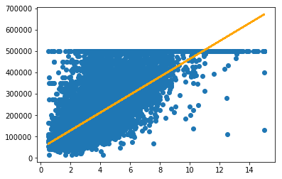

```python
# Plotting the fitted model for training and test data

plt.scatter(X_train_medInc, Y_train)
plt.plot(X_test_medInc, Y_medInc_pred,color="orange",linewidth=2)
plt.show()
```

### Additional stuff for self practice - unable to visualize the prediction on plots!!!

```python
#plt.scatter(X_train, Y_train, color = "red")
#plt.plot(X_train_std, lm.predict(X_test_std), color = "blue")
#plt.title(".........(Training set)")
#plt.xlabel(".......")
#plt.ylabel(".......")
#------------
#from sklearn_evaluation import plot

#plot.confusion_matrix(Y_test, Y_test_pred)
#plt.show()
```

```python
#plt.scatter(X_test, Y_test, color = 'gray')
#plt.plot(X_test, Y_test_pred, color = 'red', linewidth = 2)
#TestvsPred.plot(kind = 'bar', figsize = (10,8))
#plt.show()
```

----- END ----